# Seoul Bike Sharing: reproducible investigation

IDS project team

23 October 2026

## Questions and scope

We investigate the recorded relationship between hourly bike rentals, calendar patterns and weather in Seoul. The descriptive analysis uses the complete observation year. Model selection uses only the designated validation period. Every model is fixed before test evaluation. The report presents the principal visual story and the predictive limitations. This working document preserves the checks and intermediate evidence needed to reproduce those conclusions.

Repository: https://github.com/Hi-Light-Jerry/lab-04.

The source is the official UCI Seoul Bike Sharing Demand CSV, retrieved on 23 October 2026, DOI 10.24432/C5F62R. The original data carry the CC BY 4.0 licence. The source bytes remain unchanged in `data/SeoulBikeData.csv`.

## Reproduce the investigation

Run the following from the project root in RStudio. The analysis function checks the input, creates features, fits the candidate models and exports tables, diagnostic figures and machine-readable results. Re-running the script executes the same fixed protocol. It does not expand the search based on test performance.

```r
source("scripts/analysis.R")
if (!exists("analysis_results", inherits = TRUE)) {
  analysis_results <- run_analysis()
}
res <- analysis_results
source("scripts/visualisations.R")
```

The analysis implementation appears below so the full cleaning and modelling procedure can be inspected alongside its outputs.

```r
# Reproducible Seoul Bike Sharing analysis.
# Run from the RStudio project folder (project/): source("scripts/analysis.R")
# Models use observed same-hour weather; this is retrospective conditional prediction.

suppressPackageStartupMessages(library(tidyverse))

project_data_file <- function() {
  paths <- c("data/SeoulBikeData.csv", "data/raw/SeoulBikeData.csv")
  existing <- paths[file.exists(paths)]
  if (!length(existing)) stop("Place the official UCI SeoulBikeData.csv in data/ before running the analysis.")
  existing[[1]]
}

prediction_metrics <- function(observed, predicted, model, partition) {
  stopifnot(length(observed) == length(predicted), all(is.finite(predicted)))
  tibble(
    partition = partition, model = model, n = length(observed),
    rmse = sqrt(mean((observed - predicted)^2)),
    mae = mean(abs(observed - predicted)),
    r_squared = 1 - sum((observed - predicted)^2) / sum((observed - mean(observed))^2),
    mean_error = mean(predicted - observed)
  )
}

fit_calendar_baseline <- function(training) {
  list(
    cell = training |> group_by(hour, weekday) |> summarise(prediction = mean(rentals), .groups = "drop"),
    hour = training |> group_by(hour) |> summarise(hour_prediction = mean(rentals), .groups = "drop"),
    mean = mean(training$rentals)
  )
}

predict_calendar_baseline <- function(model, newdata) {
  newdata |>
    select(hour, weekday) |>
    mutate(.row = row_number()) |>
    left_join(model$cell, by = c("hour", "weekday")) |>
    left_join(model$hour, by = "hour") |>
    arrange(.row) |>
    transmute(prediction = coalesce(prediction, hour_prediction, model$mean)) |>
    pull(prediction)
}

run_analysis <- function(data_file = project_data_file(), output_root = ".") {
  set.seed(20261023)
  for (folder in c("tables", "img", "outputs")) {
    dir.create(file.path(output_root, folder), recursive = TRUE, showWarnings = FALSE)
  }
  write_table <- function(data, name) readr::write_csv(data, file.path(output_root, "tables", paste0(name, ".csv")))

  raw <- readr::read_csv(
    data_file,
    locale = readr::locale(encoding = "ISO-8859-1"),
    col_types = readr::cols(.default = readr::col_character()),
    na = c("", "NA"), show_col_types = FALSE
  )
  stopifnot(ncol(raw) == 14L, identical(names(raw)[1:3], c("Date", "Rented Bike Count", "Hour")))
  original_names <- names(raw)
  canonical_names <- c(
    "date", "rentals", "hour", "temp_c", "humidity_pct", "wind_ms",
    "visibility_10m", "dewpoint_c", "solar_mj_m2", "rainfall_mm", "snowfall_cm",
    "season", "holiday", "functioning"
  )
  names(raw) <- canonical_names
  missingness <- tibble(variable = canonical_names, missing = vapply(raw, function(x) sum(is.na(x)), integer(1)))
  write_table(missingness, "missingness")
  numeric_fields <- canonical_names[2:11]
  parsed <- raw |>
    mutate(across(all_of(numeric_fields), as.numeric), date = as.Date(date, format = "%d/%m/%Y"))
  for (field in numeric_fields) {
    if (any(!is.na(raw[[field]]) & is.na(parsed[[field]]))) stop("Unparseable numeric field: ", field)
  }
  if (any(!is.na(raw$date) & is.na(parsed$date))) stop("An input date could not be parsed as day/month/year.")
  exact_duplicates <- sum(duplicated(parsed))
  parsed <- distinct(parsed)
  if (anyDuplicated(parsed[c("date", "hour")])) stop("Conflicting duplicate date/hour records require review.")
  stopifnot(all(na.omit(parsed$hour) %in% 0:23), all(na.omit(parsed$rentals) >= 0))
  stopifnot(all(na.omit(parsed$humidity_pct) >= 0 & na.omit(parsed$humidity_pct) <= 100))
  for (field in c("wind_ms", "visibility_10m", "solar_mj_m2", "rainfall_mm", "snowfall_cm")) {
    if (any(parsed[[field]] < 0, na.rm = TRUE)) stop("Invalid negative measurement in ", field)
  }
  stopifnot(all(na.omit(parsed$functioning) %in% c("Yes", "No")),
            all(na.omit(parsed$holiday) %in% c("Holiday", "No Holiday")),
            all(na.omit(parsed$season) %in% c("Winter", "Spring", "Summer", "Autumn")))

  data <- parsed |>
    mutate(
      timestamp = as.POSIXct(paste(date, sprintf("%02d:00:00", hour)), tz = "Asia/Seoul"),
      weekday = factor(as.integer(format(date, "%u")), levels = 1:7,
                       labels = c("Mon", "Tue", "Wed", "Thu", "Fri", "Sat", "Sun")),
      hour_factor = factor(hour, levels = 0:23),
      day_type = factor(if_else(as.integer(format(date, "%u")) >= 6L | holiday == "Holiday",
                                "Weekend or holiday", "Working day"),
                        levels = c("Working day", "Weekend or holiday")),
      season = factor(season, levels = c("Winter", "Spring", "Summer", "Autumn")),
      doy = as.integer(format(date, "%j")),
      doy_sin = sin(2 * pi * (doy - 1) / 365),
      doy_cos = cos(2 * pi * (doy - 1) / 365)
    ) |>
    arrange(timestamp)
  # A complete hourly series should have a one-hour spacing throughout.
  if (any(diff(as.numeric(data$timestamp)) != 3600)) stop("Hourly timestamp coverage is incomplete or irregular.")

  required <- c("date", "rentals", "hour", "temp_c", "humidity_pct", "wind_ms",
                "visibility_10m", "solar_mj_m2", "rainfall_mm", "snowfall_cm", "weekday", "day_type")
  complete <- complete.cases(data[, required])
  active <- data |> filter(functioning == "Yes", complete)
  closures <- data |> filter(functioning == "No")
  stopifnot(nrow(active) >= 100L)
  train <- active |> filter(date <= as.Date("2018-07-31"))
  validation <- active |> filter(date >= as.Date("2018-08-01"), date <= as.Date("2018-09-30"))
  test <- active |> filter(date >= as.Date("2018-10-01"), date <= as.Date("2018-11-30"))
  stopifnot(nrow(train) > 100L, nrow(validation) > 100L, nrow(test) > 100L,
            nrow(train) + nrow(validation) + nrow(test) == nrow(active),
            max(train$timestamp) < min(validation$timestamp), max(validation$timestamp) < min(test$timestamp))
  split_summary <- bind_rows(
    train |> summarise(partition = "Training", n = n(), first_date = min(date), last_date = max(date)),
    validation |> summarise(partition = "Validation", n = n(), first_date = min(date), last_date = max(date)),
    test |> summarise(partition = "Test", n = n(), first_date = min(date), last_date = max(date))
  )
  audit <- tibble(
    check = c("input_rows", "input_columns", "exact_duplicates_removed", "missing_cells",
              "functioning_hours", "non_functioning_hours", "non_functioning_hours_with_nonzero_rentals",
              "active_rows_excluded_for_missing_values", "analysis_rows", "first_date", "last_date"),
    value = as.character(c(nrow(raw), ncol(raw), exact_duplicates, sum(is.na(raw)),
                           sum(data$functioning == "Yes", na.rm = TRUE), nrow(closures),
                           sum(closures$rentals != 0, na.rm = TRUE),
                           sum(data$functioning == "Yes" & !complete, na.rm = TRUE), nrow(active),
                           as.character(min(data$date)), as.character(max(data$date))))
  )
  write_table(audit, "data_audit")
  write_table(split_summary, "split_summary")
  variable_dictionary <- tibble(
    source_column = original_names, variable = canonical_names,
    description = c("Seoul local calendar date", "Bikes rented during this hour", "Local hour, 0 to 23",
      "Air temperature, degrees Celsius", "Relative humidity, percent", "Wind speed, metres per second",
      "Visibility in units of 10 metres", "Dew-point temperature, degrees Celsius",
      "Solar radiation, megajoules per square metre", "Rainfall, millimetres", "Snowfall, centimetres",
      "Recorded season", "Holiday or No Holiday", "Whether the bike service was functioning")
  )
  write_table(variable_dictionary, "variable_dictionary")
  dir.create(file.path(output_root, "data", "clean"), recursive = TRUE, showWarnings = FALSE)
  readr::write_csv(data, file.path(output_root, "data", "clean", "seoul_bike_clean.csv"))
  saveRDS(data, file.path(output_root, "data", "clean", "seoul_bike_clean.rds"), compress = "xz")
```

```r
  # Fixed specifications below are set before viewing test performance.
  linear_formula <- rentals ~ hour_factor * day_type + temp_c + I(temp_c^2) + humidity_pct +
    wind_ms + visibility_10m + solar_mj_m2 + log1p(rainfall_mm) + log1p(snowfall_cm) + doy_sin + doy_cos
  tree_formula <- rentals ~ hour + day_type + temp_c + humidity_pct + wind_ms + visibility_10m +
    solar_mj_m2 + rainfall_mm + snowfall_cm + doy_sin + doy_cos
  tree_controls <- rpart::rpart.control(cp = 0, minsplit = 60, minbucket = 30, maxdepth = 8, xval = 0)
  baseline_train <- fit_calendar_baseline(train)
  linear_train <- lm(linear_formula, data = train)
  tree_full_train <- rpart::rpart(tree_formula, data = train, method = "anova", control = tree_controls)
  cp_grid <- c(0, 0.0005, 0.001, 0.002, 0.005, 0.01)
  tree_tuning <- purrr::map_dfr(cp_grid, function(cp) {
    tree_candidate <- rpart::prune(tree_full_train, cp = cp)
    predictions <- pmax(0, predict(tree_candidate, newdata = validation))
    prediction_metrics(validation$rentals, predictions, "Regression tree", "Validation") |>
      mutate(cp = cp, terminal_nodes = sum(tree_candidate$frame$var == "<leaf>"))
  }) |>
    arrange(rmse, desc(cp))
  chosen_cp <- tree_tuning$cp[[1]]
  tree_train <- rpart::prune(tree_full_train, cp = chosen_cp)
  validation_predictions <- tibble(
    actual = validation$rentals,
    `Calendar baseline` = pmax(0, predict_calendar_baseline(baseline_train, validation)),
    `Linear regression` = pmax(0, predict(linear_train, newdata = validation)),
    `Regression tree` = pmax(0, predict(tree_train, newdata = validation))
  )
  model_names <- c("Calendar baseline", "Linear regression", "Regression tree")
  validation_metrics <- purrr::map_dfr(model_names, function(name)
    prediction_metrics(validation_predictions$actual, validation_predictions[[name]], name, "Validation")) |>
    arrange(rmse)
  selected_model <- validation_metrics$model[[1]]
  write_table(tree_tuning, "tree_tuning")
  write_table(validation_metrics, "validation_metrics")

  # Freeze model choice and hyperparameters, then refit on train + validation.
  development <- bind_rows(train, validation)
  fitted_models <- list(
    baseline = fit_calendar_baseline(development),
    linear = lm(linear_formula, data = development),
    tree = rpart::prune(rpart::rpart(tree_formula, data = development, method = "anova", control = tree_controls), cp = chosen_cp)
  )
  test_predictions <- test |>
    select(timestamp, date, hour, weekday, day_type, season, rentals) |>
    mutate(
      `Calendar baseline` = pmax(0, predict_calendar_baseline(fitted_models$baseline, test)),
      `Linear regression` = pmax(0, predict(fitted_models$linear, newdata = test)),
      `Regression tree` = pmax(0, predict(fitted_models$tree, newdata = test))
    )
  test_metrics <- purrr::map_dfr(model_names, function(name)
    prediction_metrics(test_predictions$rentals, test_predictions[[name]], name, "Test")) |>
    mutate(selected_on_validation = model == selected_model)
  selected_predictions <- test_predictions |>
    transmute(timestamp, date, hour, weekday, day_type, actual = rentals,
              predicted = .data[[selected_model]], error = predicted - actual)
  write_table(test_metrics, "test_metrics")
  write_table(test_predictions, "test_predictions")
  write_table(tibble(term = names(coef(fitted_models$linear)), estimate = unname(coef(fitted_models$linear))), "linear_coefficients")

  hourly_profile <- active |> group_by(day_type, hour) |>
    summarise(n = n(), mean_rentals = mean(rentals), median_rentals = median(rentals), .groups = "drop")
  monthly_summary <- active |> mutate(month = as.Date(format(date, "%Y-%m-01"))) |>
    group_by(month) |> summarise(active_hours = n(), mean_rentals = mean(rentals), total_rentals = sum(rentals), .groups = "drop")
  weather_summary <- active |> mutate(weather = if_else(rainfall_mm > 0, "Rain recorded", "No rain recorded")) |>
    group_by(weather) |> summarise(n = n(), mean_rentals = mean(rentals), median_rentals = median(rentals), .groups = "drop")
  temperature_summary <- active |> mutate(temperature_band_c = 5 * floor(temp_c / 5) + 2.5) |>
    group_by(temperature_band_c) |> summarise(n = n(), mean_rentals = mean(rentals), .groups = "drop")
  residual_hour <- selected_predictions |> group_by(hour) |>
    summarise(n = n(), mean_error = mean(error), mae = mean(abs(error)), .groups = "drop")
  write_table(hourly_profile, "hourly_profile")
  write_table(monthly_summary, "monthly_summary")
  write_table(weather_summary, "weather_summary")
  write_table(temperature_summary, "temperature_summary")
  write_table(residual_hour, "test_error_by_hour")
  numeric_summary <- purrr::map_dfr(numeric_fields, function(field) {
    x <- active[[field]]
    tibble(variable = field, n = sum(!is.na(x)), mean = mean(x, na.rm = TRUE),
           sd = sd(x, na.rm = TRUE), median = median(x, na.rm = TRUE),
           minimum = min(x, na.rm = TRUE), maximum = max(x, na.rm = TRUE))
  })
  write_table(numeric_summary, "numeric_summary_active_hours")
  stopifnot(all(is.finite(selected_predictions$predicted)),
            all(selected_predictions$predicted >= 0),
            sum(test_metrics$selected_on_validation) == 1L,
            identical(test_predictions$timestamp, test$timestamp))

  project_theme <- theme_minimal(base_size = 13) +
    theme(plot.title = element_text(face = "bold", size = 16),
          plot.subtitle = element_text(size = 11, color = "#445366"),
          panel.grid.minor = element_blank(), legend.position = "top",
          plot.caption = element_text(hjust = 0, size = 9, color = "#526074"),
          plot.background = element_rect(fill = "white", colour = NA))
  palette <- c("Working day" = "#165A72", "Weekend or holiday" = "#DC7542")
  figures <- list()
  figures$hourly_profile <- ggplot(hourly_profile, aes(hour, mean_rentals, colour = day_type)) +
    geom_line(linewidth = 1.15) + geom_point(size = 1.8) +
    scale_colour_manual(values = palette) + scale_x_continuous(breaks = seq(0, 23, 3)) +
    labs(title = "Rental demand changes across the day", subtitle = "Mean rentals per functioning hour across the full observation year",
         x = "Local hour in Seoul", y = "Mean bikes rented per hour", colour = NULL,
         caption = "Descriptive associations; weekday groups also differ in weather and season.") + project_theme
  figures$temperature <- ggplot(temperature_summary, aes(temperature_band_c, mean_rentals)) +
    geom_line(linewidth = 1, colour = "#165A72") + geom_point(aes(size = n), colour = "#165A72") +
    scale_size_continuous(range = c(2, 7), name = "Active hours") +
    labs(title = "Warmer temperature bands generally have more rentals", subtitle = "Unadjusted means in 5 C bands, functioning hours only",
         x = "Temperature band midpoint (C)", y = "Mean bikes rented per hour",
         caption = "Season, time of day and other weather variables can confound this relationship.") + project_theme
  figures$monthly <- ggplot(monthly_summary, aes(month, mean_rentals)) +
    geom_col(fill = "#165A72", width = 23) + scale_x_date(date_breaks = "1 month", date_labels = "%b") +
    labs(title = "Hourly rentals vary substantially across months", subtitle = "December 2017 to November 2018, functioning hours only",
         x = NULL, y = "Mean bikes rented per active hour",
         caption = "One observed annual cycle cannot establish a recurring seasonal effect.") + project_theme
  figures$validation <- ggplot(validation_metrics, aes(reorder(model, rmse), rmse)) +
    geom_col(fill = "#165A72", width = 0.6) + geom_text(aes(label = sprintf("%.1f", rmse)), hjust = -0.12, size = 4.5) +
    coord_flip() + expand_limits(y = max(validation_metrics$rmse) * 1.13) +
    labs(title = "Model choice uses August and September validation", subtitle = paste("Selected before test evaluation:", selected_model),
         x = NULL, y = "Validation RMSE (bikes per hour)", caption = "Lower RMSE is better; test months do not determine model selection.") + project_theme
  figures$test_predictions <- ggplot(selected_predictions, aes(actual, predicted)) +
    geom_point(alpha = 0.25, colour = "#165A72", size = 1.6) +
    geom_abline(slope = 1, intercept = 0, linetype = 2, colour = "#DC7542", linewidth = 0.9) +
    labs(title = "Predictions are evaluated on later, unseen months", subtitle = paste(selected_model, "on October and November 2018"),
         x = "Observed hourly rentals", y = "Predicted hourly rentals",
         caption = "The dashed line denotes perfect predictions. Weather is measured in the same hour.") + project_theme
  figures$test_errors <- ggplot(residual_hour, aes(hour, mean_error)) +
    geom_hline(yintercept = 0, colour = "#8B96A3", linetype = 2) +
    geom_line(colour = "#165A72", linewidth = 1.1) + geom_point(colour = "#165A72", size = 2) +
    scale_x_continuous(breaks = seq(0, 23, 3)) +
    labs(title = "Prediction bias can differ by hour", subtitle = paste("Test-set diagnostics for", selected_model),
         x = "Local hour in Seoul", y = "Mean prediction minus observation",
         caption = "Positive values indicate overprediction. Hourly observations are serially correlated.") + project_theme
  first_week <- tibble(timestamp = seq(min(test$timestamp), min(test$timestamp) + 7 * 24 * 3600 - 3600, by = "hour")) |>
    left_join(selected_predictions |> select(timestamp, actual, predicted), by = "timestamp")
  figures$test_week <- first_week |> select(timestamp, Observed = actual, Predicted = predicted) |>
    pivot_longer(-timestamp, names_to = "series", values_to = "rentals") |>
    ggplot(aes(timestamp, rentals, colour = series)) + geom_line(linewidth = 0.8, na.rm = TRUE) +
    scale_colour_manual(values = c(Observed = "#165A72", Predicted = "#DC7542")) +
    labs(title = "The first test week reveals the shape of prediction errors", subtitle = "A prespecified seven-day window beginning 1 October 2018",
         x = NULL, y = "Bikes rented per hour", colour = NULL,
         caption = "Gaps mark non-functioning hours. This illustrative week is part of the fixed test set.") + project_theme
  figure_names <- c(hourly_profile = "01_hourly_profile.png", temperature = "02_temperature.png",
                    monthly = "03_monthly_rentals.png", validation = "04_validation_rmse.png",
                    test_predictions = "05_test_predictions.png", test_errors = "06_test_hourly_bias.png",
                    test_week = "07_test_week.png")
  # The main EDA figures are built separately by scripts/visualisations.R.
  # Only compact model diagnostics are exported here; all plot objects remain in the RDS.
  for (name in c("validation", "test_errors", "test_week")) {
    ggsave(file.path(output_root, "img", figure_names[[name]]), figures[[name]], width = 9, height = 5.1, dpi = 160, bg = "white")
  }
```

```r
  source_checksum <- digest::digest(file = data_file, algo = "sha256")
  summary <- list(
    dataset = list(source = "UCI Machine Learning Repository, Seoul Bike Sharing Demand", input_file = data_file,
                   sha256 = source_checksum, raw_rows = nrow(raw), active_rows = nrow(active),
                   non_functioning_rows = nrow(closures), missing_cells = sum(is.na(raw)),
                   first_date = as.character(min(data$date)), last_date = as.character(max(data$date))),
    split = split_summary,
    selection = list(rule = "Lowest validation RMSE, before examining the fixed test partition",
                     selected_model = selected_model, tree_cp = chosen_cp,
                     tree_minbucket = 30, tree_maxdepth = 8),
    validation_metrics = validation_metrics,
    test_metrics = test_metrics,
    descriptive = list(hourly_profile = hourly_profile, monthly = monthly_summary, rain = weather_summary),
    caveats = c("Observed same-hour weather: conditional retrospective prediction, not an operational advance forecast.",
                "Active-service hours only; closures are not treated as zero-demand hours.",
                "A single city and annual cycle; temporal holdout measures a specific seasonal shift.",
                "Associational analysis does not identify causal effects.",
                "Hourly serial dependence means conventional independent-observation inference is inappropriate."),
    random_seed = 20261023
  )
  jsonlite::write_json(summary, file.path(output_root, "outputs", "results-summary.json"), pretty = TRUE, auto_unbox = TRUE, digits = 10)
  results <- list(data = data, active = active, train = train, validation = validation, test = test,
                  audit = audit, split_summary = split_summary, variable_dictionary = variable_dictionary,
                  hourly_profile = hourly_profile, monthly_summary = monthly_summary, weather_summary = weather_summary,
                  temperature_summary = temperature_summary, numeric_summary = numeric_summary, validation_metrics = validation_metrics, test_metrics = test_metrics,
                  tree_tuning = tree_tuning, selected_model = selected_model, chosen_cp = chosen_cp,
                  fitted_models = fitted_models, test_predictions = test_predictions,
                  selected_predictions = selected_predictions, residual_hour = residual_hour,
                  plots = figures, summary = summary)
  saveRDS(results, file.path(output_root, "outputs", "analysis-results.rds"), compress = "xz")
  writeLines(capture.output(sessionInfo()), file.path(output_root, "outputs", "session-info.txt"))
  message("Analysis completed. Selected on validation: ", selected_model)
  print(validation_metrics)
  print(test_metrics)
  invisible(results)
}

if (sys.nframe() == 0L) run_analysis()
```

## Input audit

Dates use day/month/year, and timestamps use Seoul local time. A date and hour pair must identify at most one observation. Numeric parsing and range checks fail explicitly when input values require review. We retain all non-functioning observations for the overview and exclude them only from the active-service demand model.

```r
knitr::kable(res$audit, caption = "Data audit produced from the original source file")
```

Data audit produced from the original source file

| check | value |
| --- | --- |
| input_rows | 8760 |
| input_columns | 14 |
| exact_duplicates_removed | 0 |
| missing_cells | 0 |
| functioning_hours | 8465 |
| non_functioning_hours | 295 |
| non_functioning_hours_with_nonzero_rentals | 0 |
| active_rows_excluded_for_missing_values | 0 |
| analysis_rows | 8465 |
| first_date | 2017-12-01 |
| last_date | 2018-11-30 |

```r
readr::read_csv("tables/missingness.csv", show_col_types = FALSE) |>
  knitr::kable(caption = "Missing entries in every original field")
```

Missing entries in every original field

| variable | missing |
| --- | --- |
| date | 0 |
| rentals | 0 |
| hour | 0 |
| temp_c | 0 |
| humidity_pct | 0 |
| wind_ms | 0 |
| visibility_10m | 0 |
| dewpoint_c | 0 |
| solar_mj_m2 | 0 |
| rainfall_mm | 0 |
| snowfall_cm | 0 |
| season | 0 |
| holiday | 0 |
| functioning | 0 |

```r
knitr::kable(res$variable_dictionary)
```

| source_column | variable | description |
| --- | --- | --- |
| Date | date | Seoul local calendar date |
| Rented Bike Count | rentals | Bikes rented during this hour |
| Hour | hour | Local hour, 0 to 23 |
| Temperature(°C) | temp_c | Air temperature, degrees Celsius |
| Humidity(%) | humidity_pct | Relative humidity, percent |
| Wind speed (m/s) | wind_ms | Wind speed, metres per second |
| Visibility (10m) | visibility_10m | Visibility in units of 10 metres |
| Dew point temperature(°C) | dewpoint_c | Dew-point temperature, degrees Celsius |
| Solar Radiation (MJ/m2) | solar_mj_m2 | Solar radiation, megajoules per square metre |
| Rainfall(mm) | rainfall_mm | Rainfall, millimetres |
| Snowfall (cm) | snowfall_cm | Snowfall, centimetres |
| Seasons | season | Recorded season |
| Holiday | holiday | Holiday or No Holiday |
| Functioning Day | functioning | Whether the bike service was functioning |

```r
digest::digest(file = "data/SeoulBikeData.csv", algo = "sha256")
```

```
## [1] "373339b71a8935d69e9af0abf26a70744632119862eeb3919efb389a7b749c60"
```

The expected SHA-256 checksum is `373339b71a8935d69e9af0abf26a70744632119862eeb3919efb389a7b749c60`.

## The principal visual evidence

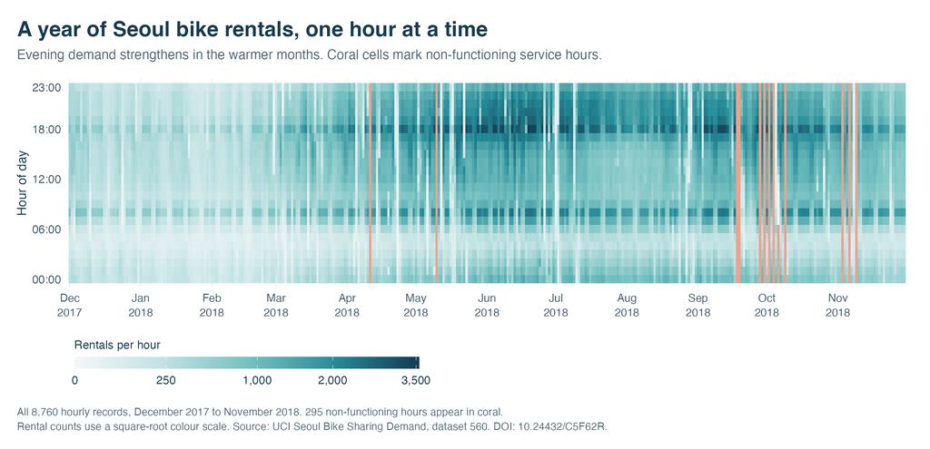

The heatmap keeps every date and hour visible, including hours when the service was not functioning. Annual differences and repeated daily variation can be considered together. The colour transformation and closure treatment appear in the visualisation source below.

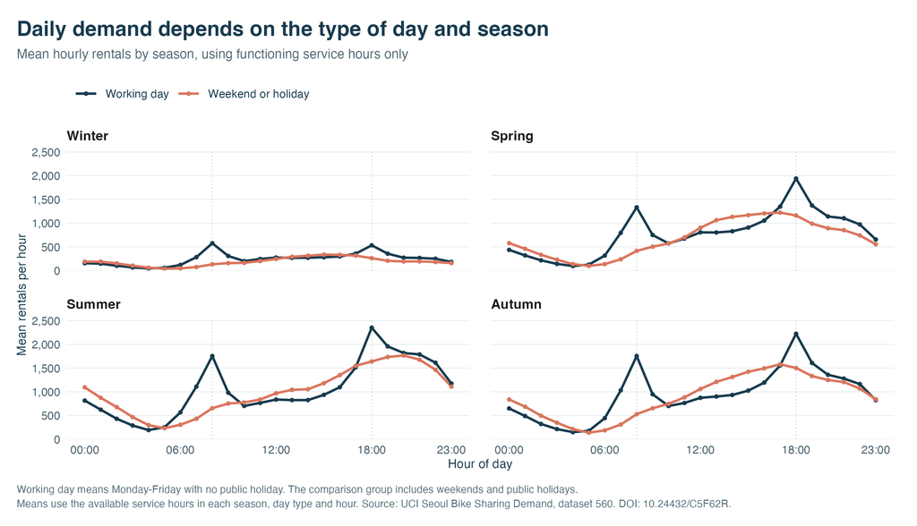

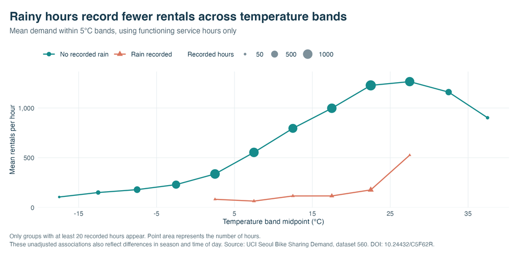

```r
# Recreate the three main descriptive figures from the original UCI CSV.
# Run from the project root in RStudio: source("scripts/visualisations.R")
# The full year is used here for descriptive summaries. The prediction analysis
# uses its own pre-specified chronological split in scripts/analysis.R.

suppressPackageStartupMessages(library(tidyverse))

if (!file.exists("data/SeoulBikeData.csv")) {
  stop("Open the project in RStudio and run this script from the project root.")
}
dir.create("img", showWarnings = FALSE)
dir.create("tables", showWarnings = FALSE)

viz_raw <- read_csv(
  "data/SeoulBikeData.csv",
  locale = locale(encoding = "Latin1"),
  show_col_types = FALSE
)
viz_data <- viz_raw |>
  transmute(
    date = as.Date(Date, format = "%d/%m/%Y"),
    hour = as.integer(Hour),
    rentals = `Rented Bike Count`,
    temperature_c = `Temperature(°C)`,
    rainfall_mm = `Rainfall(mm)`,
    season = factor(Seasons, levels = c("Winter", "Spring", "Summer", "Autumn")),
    functioning = `Functioning Day` == "Yes",
    holiday = Holiday
  ) |>
  mutate(
    day_type = factor(
      if_else(as.integer(format(date, "%u")) <= 5 & holiday == "No Holiday",
              "Working day", "Weekend or holiday"),
      levels = c("Working day", "Weekend or holiday")
    )
  )

stopifnot(
  nrow(viz_data) == 8760L,
  !anyNA(viz_data),
  !anyDuplicated(viz_data[c("date", "hour")]),
  all(viz_data$hour %in% 0:23),
  all(viz_data$rentals >= 0)
)

viz_active <- filter(viz_data, functioning)
viz_closed <- filter(viz_data, !functioning)
viz_source <- "Source: UCI Seoul Bike Sharing Demand, dataset 560. DOI: 10.24432/C5F62R."
viz_ink <- "#183B4E"
viz_teal <- "#168B8B"
viz_coral <- "#DA765E"

viz_theme <- theme_minimal(base_size = 13, base_family = "sans") +
  theme(
    text = element_text(colour = viz_ink),
    plot.title = element_text(size = 20, face = "bold", margin = margin(b = 8)),
    plot.subtitle = element_text(size = 12.5, colour = "#506672", margin = margin(b = 16)),
    plot.caption = element_text(size = 10, colour = "#536A75", hjust = 0, lineheight = 1.15,
                                margin = margin(t = 14)),
    plot.title.position = "plot",
    plot.caption.position = "plot",
    plot.background = element_rect(fill = "white", colour = NA),
    panel.grid.minor = element_blank(),
    panel.grid.major = element_line(colour = "#E4EBEE", linewidth = 0.35),
    axis.title = element_text(size = 12),
    axis.text = element_text(size = 11, colour = "#425B68"),
    legend.position = "top",
    legend.title = element_text(size = 11),
    legend.text = element_text(size = 11),
    legend.key.width = grid::unit(1.7, "lines"),
    plot.margin = margin(20, 22, 16, 16)
  )

# Figure 1. Every observation retains its date and hour. A square-root colour
# scale makes low and moderate demand visible without clipping high counts.
viz_heatmap <- ggplot(viz_active, aes(x = date, y = hour, fill = rentals)) +
  geom_tile(width = 1, height = 1) +
  geom_tile(data = viz_closed, fill = "#ECA28E", width = 1, height = 1) +
  scale_fill_gradientn(
    colours = c("#F4F7F8", "#C2E2E3", "#75C1C1", "#258D99", "#123C55"),
    transform = "sqrt",
    limits = c(0, max(viz_data$rentals)),
    breaks = c(0, 250, 1000, 2000, 3500),
    labels = scales::label_comma(),
    name = "Rentals per hour"
  ) +
  scale_x_date(
    breaks = seq(as.Date("2017-12-01"), as.Date("2018-11-01"), by = "month"),
    date_labels = "%b\n%Y",
    expand = expansion(add = 0.5)
  ) +
  scale_y_continuous(
    breaks = c(0, 6, 12, 18, 23),
    labels = c("00:00", "06:00", "12:00", "18:00", "23:00"),
    expand = expansion(add = 0.5)
  ) +
  labs(
    title = "A year of Seoul bike rentals, one hour at a time",
    subtitle = "Evening demand strengthens in the warmer months. Coral cells mark non-functioning service hours.",
    x = NULL, y = "Hour of day",
    caption = paste0(
      "All 8,760 hourly records, December 2017 to November 2018. ",
      nrow(viz_closed), " non-functioning hours appear in coral.\n",
      "Rental counts use a square-root colour scale. ", viz_source
    )
  ) +
  guides(fill = guide_colourbar(
    direction = "horizontal", title.position = "top", title.hjust = 0,
    barwidth = grid::unit(115, "mm"), barheight = grid::unit(4, "mm")
  )) +
  viz_theme +
  theme(
    legend.position = "bottom", legend.justification = "left",
    panel.grid = element_blank(),
    axis.text.x = element_text(size = 10.5, lineheight = 1.1)
  )

ggsave("img/fig-01-demand-heatmap.png", viz_heatmap,
       width = 12.2, height = 5.9, dpi = 220, bg = "white")

# Figure 2. Each mean counts the functioning observations in its particular
# season, day type and hour. Working days are Monday-Friday non-holidays.
viz_hourly <- viz_active |>
  group_by(season, day_type, hour) |>
  summarise(n_hours = n(), mean_rentals = mean(rentals), .groups = "drop")
viz_profile_denominators <- viz_active |>
  group_by(season, day_type) |>
  summarise(n_dates = n_distinct(date), n_hours = n(), .groups = "drop")
viz_profile_peaks <- viz_hourly |>
  group_by(season, day_type) |>
  slice_max(mean_rentals, n = 1, with_ties = FALSE) |>
  ungroup()

viz_profiles <- ggplot(viz_hourly, aes(hour, mean_rentals, colour = day_type)) +
  geom_vline(xintercept = c(8, 18), linetype = "dotted", colour = "#BBCBD2", linewidth = 0.4) +
  geom_line(linewidth = 1.1) +
  geom_point(size = 1.25) +
  facet_wrap(vars(season), ncol = 2) +
  scale_colour_manual(values = c("Working day" = viz_ink, "Weekend or holiday" = viz_coral), name = NULL) +
  scale_x_continuous(breaks = c(0, 6, 12, 18, 23),
                     labels = c("00:00", "06:00", "12:00", "18:00", "23:00")) +
  scale_y_continuous(labels = scales::label_comma(), limits = c(0, NA),
                     expand = expansion(mult = c(0, 0.08))) +
  labs(
    title = "Daily demand depends on the type of day and season",
    subtitle = "Mean hourly rentals by season, using functioning service hours only",
    x = "Hour of day", y = "Mean rentals per hour",
    caption = paste0(
      "Working day means Monday-Friday with no public holiday. The comparison group includes weekends and public holidays.\n",
      "Means use the available service hours in each season, day type and hour. ",
      viz_source
    )
  ) +
  viz_theme +
  theme(
    strip.text = element_text(face = "bold", size = 13, hjust = 0, margin = margin(b = 8, t = 6)),
    panel.spacing = grid::unit(1.4, "lines"),
    legend.justification = "left", legend.box.just = "left",
    panel.grid.major.x = element_blank()
  )

ggsave("img/fig-02-hourly-profiles.png", viz_profiles,
       width = 12.2, height = 7.0, dpi = 220, bg = "white")

# Figure 3. Compare rain groups within fixed 5-degree bands. This is an
# unadjusted descriptive comparison: temperature, hour and season can covary.
viz_weather <- viz_active |>
  mutate(
    temperature_band_low = floor(temperature_c / 5) * 5,
    temperature_band_mid = temperature_band_low + 2.5,
    rain_group = factor(
      if_else(rainfall_mm > 0, "Rain recorded", "No recorded rain"),
      levels = c("No recorded rain", "Rain recorded")
    )
  ) |>
  group_by(temperature_band_low, temperature_band_mid, rain_group) |>
  summarise(n_hours = n(), mean_rentals = mean(rentals), .groups = "drop") |>
  mutate(displayed = n_hours >= 20)

viz_weather_plot <- ggplot(
  filter(viz_weather, displayed),
  aes(temperature_band_mid, mean_rentals, colour = rain_group, shape = rain_group)
) +
  geom_line(linewidth = 0.9) +
  geom_point(aes(size = n_hours), stroke = 0.75) +
  scale_colour_manual(values = c("No recorded rain" = viz_teal, "Rain recorded" = viz_coral), name = NULL) +
  scale_shape_manual(values = c("No recorded rain" = 16, "Rain recorded" = 17), name = NULL) +
  scale_size_area(max_size = 7.5, breaks = c(50, 500, 1000), name = "Recorded hours") +
  scale_x_continuous(breaks = seq(-15, 35, 10)) +
  scale_y_continuous(labels = scales::label_comma(), limits = c(0, NA),
                     expand = expansion(mult = c(0, 0.08))) +
  labs(
    title = "Rainy hours record fewer rentals across temperature bands",
    subtitle = "Mean demand within 5°C bands, using functioning service hours only",
    x = "Temperature band midpoint (°C)", y = "Mean rentals per hour",
    caption = paste0(
      "Only groups with at least 20 recorded hours appear. Point area represents the number of hours.\n",
      "These unadjusted associations also reflect differences in season and time of day. ", viz_source
    )
  ) +
  viz_theme +
  guides(
    colour = guide_legend(order = 1, override.aes = list(size = 3)),
    shape = guide_legend(order = 1),
    size = guide_legend(order = 2, override.aes = list(colour = "#7D909A", shape = 16))
  ) +
  theme(legend.justification = "left", legend.box.just = "left")

ggsave("img/fig-03-weather-demand.png", viz_weather_plot,
       width = 12.2, height = 6.0, dpi = 220, bg = "white")

write_csv(viz_hourly, "tables/viz-hourly-profiles.csv")
write_csv(viz_profile_denominators, "tables/viz-profile-denominators.csv")
write_csv(viz_profile_peaks, "tables/viz-profile-peaks.csv")
write_csv(viz_weather, "tables/viz-weather-bands.csv")

viz_overview <- viz_data |>
  summarise(
    total_hours = n(), active_hours = sum(functioning), closed_hours = sum(!functioning),
    first_date = as.character(min(date)), last_date = as.character(max(date)),
    max_hourly_rentals = max(rentals), total_rentals = sum(rentals)
  )
viz_rain_summary <- viz_active |>
  mutate(rain_group = if_else(rainfall_mm > 0, "Rain recorded", "No recorded rain")) |>
  group_by(rain_group) |>
  summarise(n_hours = n(), mean_rentals = mean(rentals), .groups = "drop")

viz_findings <- list(
  scope = "Descriptive summaries across the full observed year. Model evaluation has a separate chronological split.",
  overview = viz_overview,
  hourly_peaks = viz_profile_peaks,
  rain_summary = viz_rain_summary,
  main_finding = "The heatmap shows stronger evening demand in the warmer months, alongside a much quieter winter.",
  profile_finding = "The mean working-day peak occurs at 18:00 in spring, summer and autumn, and at 08:00 in winter.",
  weather_finding = "For displayed temperature bands containing at least 20 hours per rain group, rainy hours have lower mean rentals than dry hours in every overlapping band.",
  caveat = "All findings describe observed associations, with no causal interpretation. Non-functioning service hours are shown separately in the heatmap and excluded from the profile and weather means.",
  source = "Seoul Bike Sharing Demand (2020), UCI Machine Learning Repository, https://doi.org/10.24432/C5F62R, CC BY 4.0. Retrieved 23 October 2026."
)
jsonlite::write_json(viz_findings, "tables/viz-findings.json", auto_unbox = TRUE,
                     pretty = TRUE, dataframe = "rows", digits = 8)
message("Created the three descriptive figures and their summary tables.")
```

## Descriptive summaries

These summaries use functioning hours across the full year. They describe observed associations and do not estimate causal effects. In particular, temperature, precipitation, time of day and season can vary together.

```r
knitr::kable(res$monthly_summary, digits = 1)
```

| month | active_hours | mean_rentals | total_rentals |
| --- | --- | --- | --- |
| 2017-12-01 | 744 | 249.1 | 185330 |
| 2018-01-01 | 744 | 201.6 | 150006 |
| 2018-02-01 | 672 | 225.9 | 151833 |
| 2018-03-01 | 744 | 511.6 | 380594 |
| 2018-04-01 | 696 | 753.2 | 524227 |
| 2018-05-01 | 720 | 982.1 | 707088 |
| 2018-06-01 | 720 | 1245.7 | 896887 |
| 2018-07-01 | 744 | 987.2 | 734460 |
| 2018-08-01 | 744 | 876.2 | 651887 |
| 2018-09-01 | 624 | 1079.5 | 673612 |
| 2018-10-01 | 665 | 978.5 | 650675 |
| 2018-11-01 | 648 | 718.7 | 465715 |

```r
knitr::kable(res$weather_summary, digits = 1)
```

| weather | n | mean_rentals | median_rentals |
| --- | --- | --- | --- |
| No rain recorded | 7949 | 765.6 | 591 |
| Rain recorded | 516 | 167.3 | 71 |

```r
knitr::kable(res$hourly_profile, digits = 1)
```

| day_type | hour | n | mean_rentals | median_rentals |
| --- | --- | --- | --- | --- |
| Working day | 0 | 238 | 515.9 | 501.5 |
| Working day | 1 | 238 | 395.6 | 386.0 |
| Working day | 2 | 238 | 268.8 | 255.5 |
| Working day | 3 | 238 | 177.8 | 168.5 |
| Working day | 4 | 238 | 121.0 | 113.5 |
| Working day | 5 | 238 | 154.1 | 148.5 |
| Working day | 6 | 238 | 362.4 | 368.5 |
| Working day | 7 | 238 | 805.3 | 828.0 |
| Working day | 8 | 238 | 1353.5 | 1578.0 |
| Working day | 9 | 238 | 746.8 | 851.5 |
| Working day | 10 | 238 | 543.2 | 606.0 |
| Working day | 11 | 238 | 612.1 | 644.0 |
| Working day | 12 | 238 | 696.8 | 718.0 |
| Working day | 13 | 238 | 697.7 | 706.5 |
| Working day | 14 | 238 | 712.4 | 715.0 |
| Working day | 15 | 238 | 785.1 | 783.0 |
| Working day | 16 | 238 | 908.9 | 916.0 |
| Working day | 17 | 238 | 1194.8 | 1291.5 |
| Working day | 18 | 238 | 1766.3 | 1932.0 |
| Working day | 19 | 238 | 1330.7 | 1445.0 |
| Working day | 20 | 238 | 1156.5 | 1225.0 |
| Working day | 21 | 238 | 1119.0 | 1193.0 |
| Working day | 22 | 238 | 1008.2 | 1057.5 |
| Working day | 23 | 238 | 715.4 | 683.5 |
| Weekend or holiday | 0 | 114 | 656.6 | 694.0 |
| Weekend or holiday | 1 | 114 | 538.6 | 538.0 |
| Weekend or holiday | 2 | 114 | 404.7 | 413.0 |
| Weekend or holiday | 3 | 114 | 279.8 | 288.5 |
| Weekend or holiday | 4 | 114 | 171.9 | 170.0 |
| Weekend or holiday | 5 | 114 | 123.6 | 107.0 |
| Weekend or holiday | 6 | 114 | 164.1 | 141.0 |
| Weekend or holiday | 7 | 115 | 256.9 | 259.0 |
| Weekend or holiday | 8 | 115 | 422.5 | 439.0 |
| Weekend or holiday | 9 | 115 | 504.7 | 526.0 |
| Weekend or holiday | 10 | 115 | 551.1 | 563.0 |
| Weekend or holiday | 11 | 115 | 640.3 | 592.0 |
| Weekend or holiday | 12 | 115 | 777.8 | 754.0 |
| Weekend or holiday | 13 | 115 | 883.2 | 843.0 |
| Weekend or holiday | 14 | 115 | 934.2 | 919.0 |
| Weekend or holiday | 15 | 115 | 1006.9 | 946.0 |
| Weekend or holiday | 16 | 115 | 1072.7 | 974.0 |
| Weekend or holiday | 17 | 115 | 1140.8 | 1011.0 |
| Weekend or holiday | 18 | 115 | 1114.7 | 934.0 |
| Weekend or holiday | 19 | 115 | 1039.3 | 957.0 |
| Weekend or holiday | 20 | 115 | 999.3 | 877.0 |
| Weekend or holiday | 21 | 115 | 957.8 | 983.0 |
| Weekend or holiday | 22 | 115 | 842.3 | 841.0 |
| Weekend or holiday | 23 | 115 | 649.6 | 655.0 |

## A fixed chronological evaluation

The intended boundaries are training through 31 July 2018, validation from 1 August to 30 September, and test from 1 October to 30 November. Table dates show the first and last available functioning observations within each boundary, so a closure can make the last observed date earlier than the boundary.

```r
knitr::kable(res$split_summary)
```

| partition | n | first_date | last_date |
| --- | --- | --- | --- |
| Training | 5784 | 2017-12-01 | 2018-07-31 |
| Validation | 1368 | 2018-08-01 | 2018-09-29 |
| Test | 1313 | 2018-10-01 | 2018-11-30 |

The calendar baseline uses the training mean within each hour and weekday. The linear model uses hour and day type, weather measurements, quadratic temperature and two annual sine and cosine terms. Dew-point temperature is excluded because it overlaps strongly with other temperature and humidity information. The tree uses a fixed depth limit, minimum leaf size and a six-value pruning grid. No season factor is required, which avoids introducing an unseen categorical season at prediction time.

The weather predictors are observed in the response hour. Accordingly, the task is retrospective conditional prediction. A deployed advance forecast would need a separate protocol that uses only weather forecasts available when predictions are issued.

```r
knitr::kable(res$tree_tuning, digits = 3,
             caption = "Tree pruning comparison on validation data only")
```

Tree pruning comparison on validation data only

| partition | model | n | rmse | mae | r_squared | mean_error | cp | terminal_nodes |
| --- | --- | --- | --- | --- | --- | --- | --- | --- |
| Validation | Regression tree | 1368 | 364.018 | 246.202 | 0.677 | -43.047 | 0.000 | 54 |
| Validation | Regression tree | 1368 | 364.359 | 246.917 | 0.676 | -45.606 | 0.001 | 41 |
| Validation | Regression tree | 1368 | 371.938 | 260.072 | 0.662 | -21.721 | 0.002 | 29 |
| Validation | Regression tree | 1368 | 373.131 | 251.544 | 0.660 | -74.577 | 0.000 | 91 |
| Validation | Regression tree | 1368 | 401.028 | 284.330 | 0.607 | -17.135 | 0.005 | 19 |
| Validation | Regression tree | 1368 | 436.030 | 338.630 | 0.536 | 94.327 | 0.010 | 10 |

```r
knitr::kable(res$validation_metrics, digits = 3)
```

| partition | model | n | rmse | mae | r_squared | mean_error |
| --- | --- | --- | --- | --- | --- | --- |
| Validation | Regression tree | 1368 | 364.018 | 246.202 | 0.677 | -43.047 |
| Validation | Linear regression | 1368 | 420.424 | 333.790 | 0.569 | 25.820 |
| Validation | Calendar baseline | 1368 | 543.333 | 422.723 | 0.279 | -324.982 |

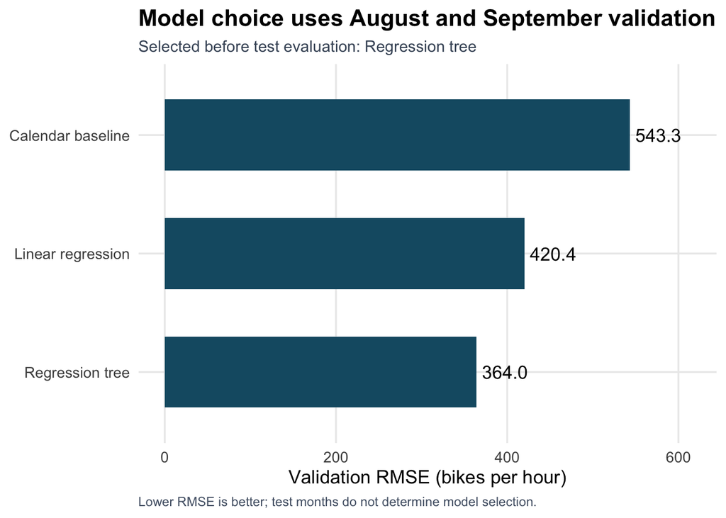

The model with the lowest validation RMSE is **Regression tree**. Its selection remains fixed when the test set is examined. The model is refitted on the combined training and validation periods, with its selected specification unchanged.

## Test performance and diagnostics

Every frozen candidate is evaluated on the same test observations. Reporting the alternatives makes a validation-to-test ranking reversal visible. It does not change the validation-selected headline model.

```r
knitr::kable(res$test_metrics, digits = 3)
```

| partition | model | n | rmse | mae | r_squared | mean_error | selected_on_validation |
| --- | --- | --- | --- | --- | --- | --- | --- |
| Test | Calendar baseline | 1313 | 386.124 | 276.010 | 0.527 | -142.260 | FALSE |
| Test | Linear regression | 1313 | 353.077 | 284.241 | 0.604 | -243.130 | FALSE |
| Test | Regression tree | 1313 | 438.861 | 307.055 | 0.389 | -249.031 | TRUE |

RMSE gives large errors extra weight, while MAE averages their absolute size. Mean error is prediction minus observation, so negative values indicate underprediction. Test R-squared compares squared error against a predictor equal to the test-sample mean and can be negative.

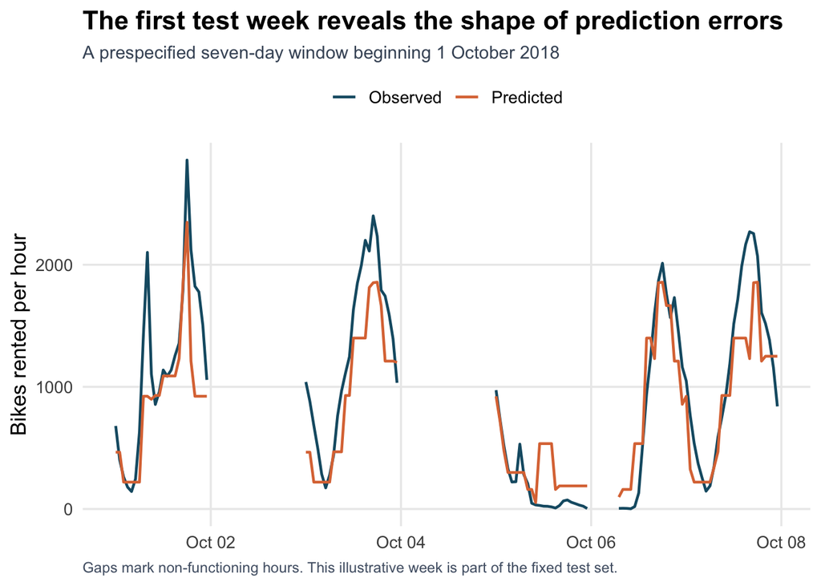

The seven-day display starts at the beginning of the fixed test period. It provides an illustration of errors rather than a replacement for the metrics covering all test observations.

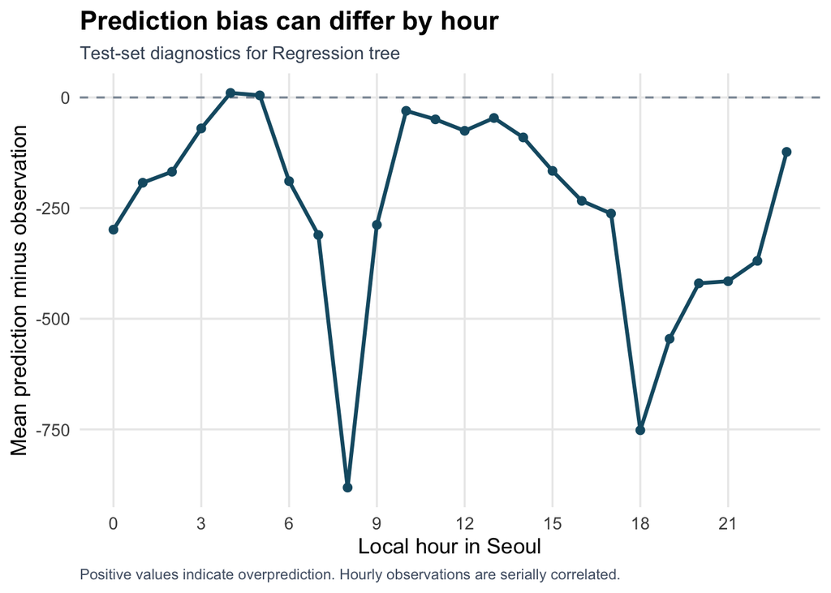

A systematic pattern in mean error by hour can identify a model weakness. This is a diagnostic for future work. Adjusting the model after seeing it would require a fresh evaluation period.

## Limits and next investigations

Only one city and one annual cycle are represented. The chronological split therefore measures performance through a particular seasonal transition. Hourly observations may be serially dependent, and no conventional independent-error significance tests are used here. Rentals can be constrained by supply, so they are an incomplete measure of underlying customer demand. The active-service analysis also leaves closure prediction outside its scope.

Useful extensions include multiple years, validation over successive time windows, forecast weather inputs and station-level availability. These extensions require new data or a new evaluation protocol. They are not presented as completed work.

## References

Seoul Bike Sharing Demand [Dataset]. (2020). UCI Machine Learning Repository. https://doi.org/10.24432/C5F62R. Retrieved 23 October 2026. [CC BY 4.0](https://creativecommons.org/licenses/by/4.0/).

University of Edinburgh. *Introduction to Data Science: Final Projects*. https://uoe-ids.netlify.app/assessments/project/. Structure adapted from https://github.com/uoeIDS/project_template.